# Assignment 5

Daniel Stewart

October 16, 2019

Installed Packages:

- install.packages(“tidyverse”)
- install.packages(“singer”)
- install.packages(“ggplot2”)
- install.packages(“tidyr”)
- install.packages(“readr”)
- install.packages(“ggpubr”)

**Note to reviewers: “ggpubr” may not be installed on your device**

## Exercise 1: The Value of here::here Package

This function is a powerful tool for reliably constructing pathways to files based on the current directory at the time the package is loaded. Unlike setwd(), which is fragile to any change in directories, platforms or file names, here::here is flexible and adaptive, capable of locating files using reasonable heuristics.

As a result of this adaptive file search power, it is much easier to use sub-directories within projects, and we can now easily avoid problematic and clunky alternatives (e.g. set(wd), rm(lst = ls()), large directories). We can also move files freely within the project directory without having to change any relative directory. In short, the power of here is that it reduces many of the headaches associated with sharing/moving/renaming data between platforms and devices.

## Exercise 2: Factor Management

### Part A: pre-Modified gapminder data

```r
levels(gapminder$continent) #number/names  of continents
```

```
## [1] "Africa"   "Americas" "Asia"     "Europe"   "Oceania"
```

```r
nlevels(gapminder$country) #number of countries
```

```
## [1] 142
```

```r
gapminder
```

```
## # A tibble: 1,704 x 6
##    country     continent  year lifeExp      pop gdpPercap
##    <fct>       <fct>     <int>   <dbl>    <int>     <dbl>
##  1 Afghanistan Asia       1952    28.8  8425333      779.
##  2 Afghanistan Asia       1957    30.3  9240934      821.
##  3 Afghanistan Asia       1962    32.0 10267083      853.
##  4 Afghanistan Asia       1967    34.0 11537966      836.
##  5 Afghanistan Asia       1972    36.1 13079460      740.
##  6 Afghanistan Asia       1977    38.4 14880372      786.
##  7 Afghanistan Asia       1982    39.9 12881816      978.
##  8 Afghanistan Asia       1987    40.8 13867957      852.
##  9 Afghanistan Asia       1992    41.7 16317921      649.
## 10 Afghanistan Asia       1997    41.8 22227415      635.
## # ... with 1,694 more rows
```

### Part B: Modified gapminder data

```r
Filtered_gapminder <- gapminder %>%
  filter(continent != "Oceania") %>%
  droplevels()

levels(Filtered_gapminder$continent) #number/names of continents
```

```
## [1] "Africa"   "Americas" "Asia"     "Europe"
```

```r
nlevels(Filtered_gapminder$country) #number of countries
```

```
## [1] 140
```

```r
Filtered_gapminder
```

```
## # A tibble: 1,680 x 6
##    country     continent  year lifeExp      pop gdpPercap
##    <fct>       <fct>     <int>   <dbl>    <int>     <dbl>
##  1 Afghanistan Asia       1952    28.8  8425333      779.
##  2 Afghanistan Asia       1957    30.3  9240934      821.
##  3 Afghanistan Asia       1962    32.0 10267083      853.
##  4 Afghanistan Asia       1967    34.0 11537966      836.
##  5 Afghanistan Asia       1972    36.1 13079460      740.
##  6 Afghanistan Asia       1977    38.4 14880372      786.
##  7 Afghanistan Asia       1982    39.9 12881816      978.
##  8 Afghanistan Asia       1987    40.8 13867957      852.
##  9 Afghanistan Asia       1992    41.7 16317921      649.
## 10 Afghanistan Asia       1997    41.8 22227415      635.
## # ... with 1,670 more rows
```

The original gapminder dataset contained 5 continents, 142 countries and 1,704 rows. My filtering work reduced this dataset to 4 continents, 140 countries and 1,680 rows.

### Part C: Reordering of factors

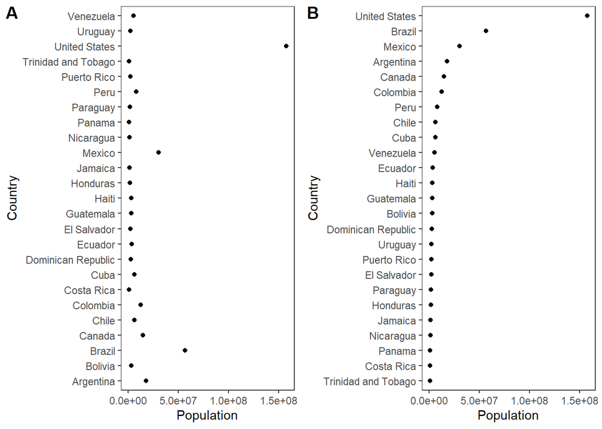

```r
Populations_NA <- Filtered_gapminder %>%
  group_by(country) %>%
  filter(year==1952, continent == "Americas") %>%
  summarise(population = mean(pop, na.rm =TRUE))

#Un-ordered
unordered <- ggplot(Populations_NA, aes(population, country)) +
  geom_point() +
  labs(x= "Population", y = "Country") +
  theme_bw() + #removes background
  theme(panel.grid.major = element_blank(), panel.grid.minor = element_blank())

#Re-ordered
ordered <-ggplot(Populations_NA, aes(population, fct_reorder(country, population))) +
  geom_point() +
  labs(x= "Population", y = "Country") +
  theme_bw() + #removes background
  theme(panel.grid.major = element_blank(), panel.grid.minor = element_blank())

COMPARISON <-ggpubr::ggarrange(unordered, ordered,
                    labels = c("A", "B"),
                    ncol = 2, nrow = 1)
COMPARISON
```

The above plots demonstrate the ability of using “fct_reorder” to manipulate how you display data. Plot A was ordered in reverse alphabetical (default setting), whereas Plot B was reordered from highest population to lowest.

## Exercise 3: File input/output (I/O)

### Part A: Grouping & exporting 2007 gapminder data

```r
Data_2007 <- gapminder %>%
  filter(year == 2007) %>%
  mutate(population_level = factor(case_when(pop < 10000000 ~ 'very low',
                            pop < 50000000 ~ 'low',
                            pop < 100000000 ~ 'moderate',
                            pop < 500000000 ~ 'high',
                            TRUE ~ 'very high'),
  levels = c("very low", "low","moderate", "high","very high")))

write_csv(Data_2007, here::here("hw05","Data_2007.csv"))
```

### Part B: Importing the previous dataset

```r
read_csv(here::here("hw05","Data_2007.csv"))
```

```
## # A tibble: 142 x 7
##    country     continent  year lifeExp       pop gdpPercap population_level
##    <chr>       <chr>     <dbl>   <dbl>     <dbl>     <dbl> <chr>
##  1 Afghanistan Asia       2007    43.8  31889923      975. low
##  2 Albania     Europe     2007    76.4   3600523     5937. very low
##  3 Algeria     Africa     2007    72.3  33333216     6223. low
##  4 Angola      Africa     2007    42.7  12420476     4797. low
##  5 Argentina   Americas   2007    75.3  40301927    12779. low
##  6 Australia   Oceania    2007    81.2  20434176    34435. low
##  7 Austria     Europe     2007    79.8   8199783    36126. very low
##  8 Bahrain     Asia       2007    75.6    708573    29796. very low
##  9 Bangladesh  Asia       2007    64.1 150448339     1391. high
## 10 Belgium     Europe     2007    79.4  10392226    33693. low
## # ... with 132 more rows
```

## Exercise 4: Visualization design

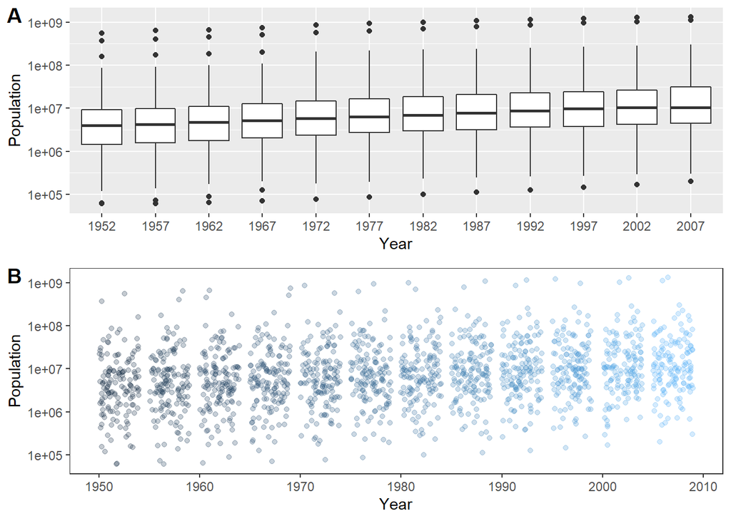

```r
OLDPLOT <- ggplot(gapminder) +
  geom_boxplot (aes(factor(year), pop)) +
  xlab("Year") +
  ylab("Population") +
  scale_y_log10()

REVISEDPLOT <- gapminder %>%
  ggplot() +
  geom_jitter(aes(year, pop, color = year),show.legend = FALSE, alpha = 0.25) + #removes unneccessary legend
  scale_y_log10() +
  labs(x="Year", y="Population") +
  theme_bw() + #removes background
  theme(panel.grid.major = element_blank(), panel.grid.minor = element_blank()) #removes gridlines


COMBINED <-ggpubr::ggarrange(OLDPLOT, REVISEDPLOT,
                    labels = c("A", "B"),
                    ncol = 1, nrow = 2)
COMBINED
```

Above is a plot that I created for Assignment 2 (A) and a revised plot using the same data for this assignment (B). To improve plot A I removed the grey background, converted the boxplot format to jitter to improve viewability, and added a colour gradient to help in distinguishing years.

## Exercise 5

### Part A: Saving a .png of the revised jitter plot

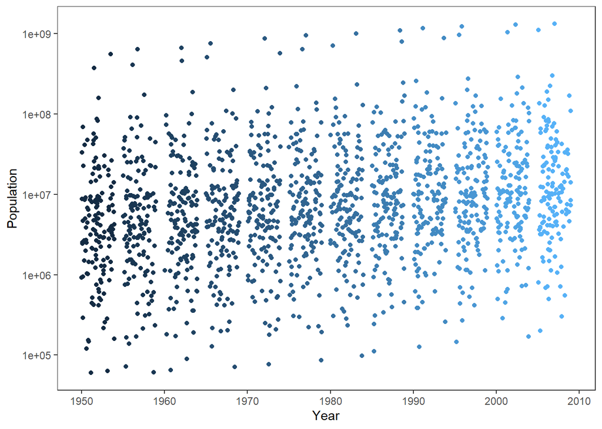

```r
gapminder %>%
  ggplot() +
  geom_jitter(aes(year, pop, color = year),show.legend = FALSE) + #removes unneccessary legend
  scale_y_log10() +
  labs(x="Year", y="Population") +
  theme_bw() + #removes background
  theme(panel.grid.major = element_blank(), panel.grid.minor = element_blank())
```

```r
  ggsave(file="revised_jitter.png", scale = 1, width = 10, height = 5) # adjusted plot size
```

### Part B: Loading and embedding this .png to my report

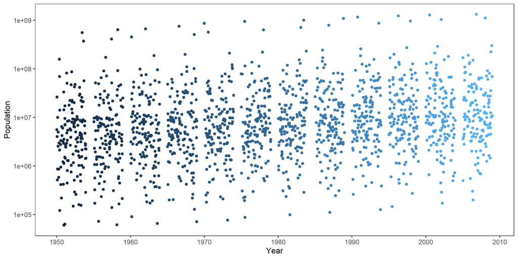